# Investigating the demographic and socioeconomic traits of people in UK 2021

## 3.5 Count of Households with Individuals Aged over 60 by Marital Status

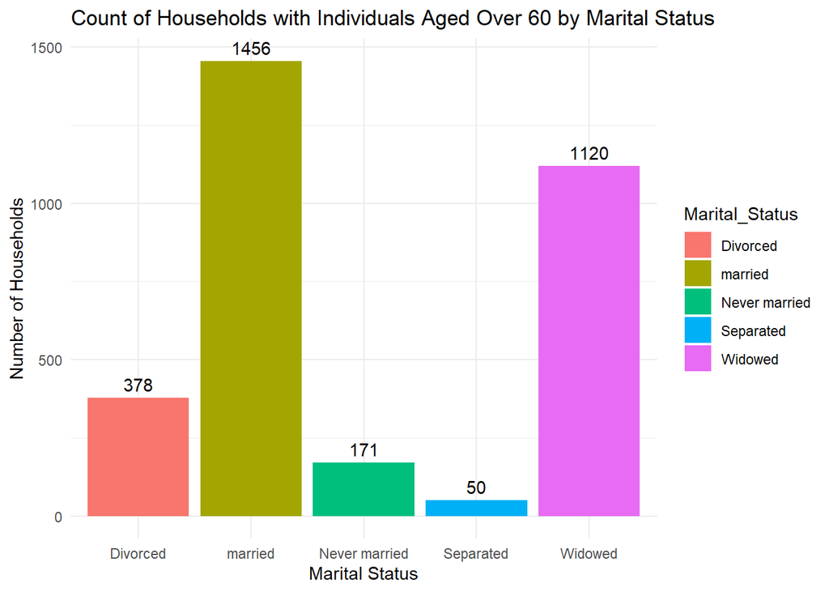

Figure 5: Count of Households with people age over 60 and their marital status

```r
households_over_60 <- data %>%
     filter(Age > 60) %>%
     group_by(ID, Marital_Status) %>%
     summarise(Frequency = n())
ggplot(households_over_60, aes(x = Marital_Status, fill = Marital_Status)) +
      geom_bar() +
      geom_text(stat = "count", aes(label = ..count..), vjust = -0.5) +
      ggtitle("Count of Households with Individuals Aged Over 60 by Marital Status") +
      xlab("Marital Status") +
      ylab("Number of Households") +
      theme_minimal()
```

From the above Figure 5 , the number of households has been calculated where people is over 60 and their marital status. It shows that 1456 households has married old age people. there are few number of households with separated , never married and divorced people. This graph could help Government to analyse which households or number of households need career assistant. So old aged people who are living alone might get help from this data.

# 4 Conclusion

This analysis provided insights into the demographic and socioeconomic traits of people in the UK in 2021. It highlighted several key findings, including:

- A significant portion of the population (63.7%) has an annual income less than £17,700.
- Low-income individuals are more likely to be young (19-30) or old (60+).
- Educational attainment is a significant factor in determining income levels, with those with less than a secondary education being more likely to be in low-income households.
- Income disparities exist between ethnicities and genders, with White and Hispanic males earning more than other groups.
- Asian individuals are more likely to live in shared accommodation, potentially due to lower income levels.
- A considerable number of households (1456) have individuals aged over 60 who are married.

These findings suggest that there is a need for policies and interventions to address low income, educational disparities, and income inequalities. Additionally, support systems for older individuals living alone should be considered. By addressing these issues, the UK can work towards a more equitable and just society for all.

## References

GOV.UK. 2023. “People in low income households - GOV.UK Ethnicity facts and figures.” https://www.ethnicity-facts-figures.service.gov.uk/work-pay-and-benefits/pay-and-income/low-income/latest.

National Statistics, Office for. 2023. “Office for National Statistics.” https://www.ons.gov.uk/.

Wickham, Hadley. 2016. “Ggplot2: Elegant Graphics for Data Analysis.” https://ggplot2.tidyverse.org.

Wickham, Hadley, Mara Averick, Jennifer Bryan, Winston Chang, Lucy D’Agostino McGowan, Romain François, Garrett Grolemund, et al. 2019. “Welcome to the Tidyverse” 4: 1686. https://doi.org/10.21105/joss.01686.